# Project Analysis

## Wrangle and Analyze Data - Udacity DAND Project

### Overview:

The dataset that we have done wrangling on (and analyzing and visualizing) is the tweet archive of Twitter user @dog_rates, also known as WeRateDogs. WeRateDogs is a Twitter account that rates people's dogs with a humorous comment about the dog. These ratings almost always have a denominator of 10. The numerators, though? Almost always greater than 10. 11/10, 12/10, 13/10, etc. Why? Because "they're good dogs Brent." WeRateDogs has over 4 million followers and has received international media coverage.

```python
import numpy as np
import pandas as pd
import seaborn as sns
import matplotlib.pyplot as plt
%matplotlib inline
```

```python
df_analysis = pd.read_csv('/Users/anshulrampal/Downloads/twitter_archive_master.csv')
df_analysis['timestamp'] = pd.to_datetime(df_analysis['timestamp'])
df_analysis.set_index('timestamp', inplace=True)
```

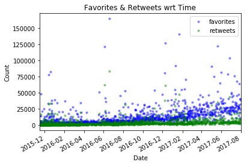

```python
df_analysis[['favorites', 'retweets']].plot(style = '.', alpha = 0.4,color=['blue','green'])
plt.title('Favorites & Retweets wrt Time')
plt.xlabel('Date')
plt.ylabel('Count');
```

As can be observed from the diagram that the number of favorites and retweets were increased with time.

```python
df_analysis.loc[:,['favorites','retweets']].describe()
```

|  | favorites | retweets |
| --- | --- | --- |
| count | 1994.000000 | 1994.000000 |
| mean | 8744.323972 | 2657.697593 |
| std | 12823.484178 | 4736.646102 |
| min | 0.000000 | 0.000000 |
| 25% | 1877.250000 | 591.500000 |
| 50% | 3940.500000 | 1273.500000 |
| 75% | 10912.500000 | 3046.000000 |
| max | 164586.000000 | 83834.000000 |

The minimum number of retweets and favourites were assigned by us i.e. 0 for 2 of the records above. Also, we can see that on an average 8744 times the the tweet was liked and 2657 times it was retweet. Also max retweets for any tweet was 83834.

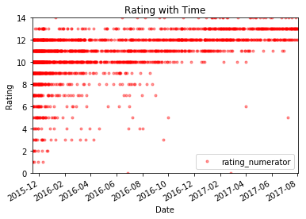

```python
df_analysis.plot(y ='rating_numerator', ylim=[0,14], style = '.', alpha = 0.4, color='red')
plt.title('Rating with Time')
plt.xlabel('Date')
plt.ylabel('Rating');
```

The above plot exactly tells what we observed from the prior information avaiable. The dog ratings are more than 10 for most of the tweets.

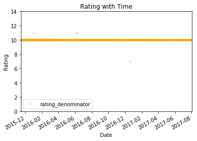

```python
df_analysis.plot(y ='rating_denominator', ylim=[0,14], style = '.', alpha = 0.4,color='orange')
plt.title('Rating with Time')
plt.xlabel('Date')
plt.ylabel('Rating');
```

This plot explains the denominator rating which is consistent 10. Somewhere there are 11 or 7 as the denominator but that doesn't effect the analysis since largely the ratings are out of 10

```python
df_analysis[['favorites', 'rating_numerator', 'retweets']].corr(method='pearson')
```

|  | favorites | rating_numerator | retweets |
| --- | --- | --- | --- |
| favorites | 1.000000 | 0.015884 | 0.929647 |
| rating_numerator | 0.015884 | 1.000000 | 0.018127 |
| retweets | 0.929647 | 0.018127 | 1.000000 |

As we can observe from the visualisations, there are many dogs (a lot of them !) who got more than 12 rating. Yet this is strange since normally rating needs to be withing the provided denominator range.

We can check if the dogs who got higher scores/rating, are they getting retweets or favourites too. And when we checked and analysed the same, we found that this generally doesn't hold true for most of the dogs. Getting more rating doesn't guarantee the dogs were retweeted or were liked (favorites).

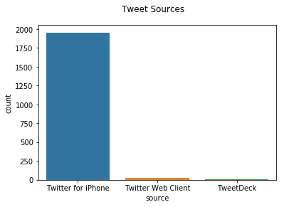

```python
p = sns.countplot(data=df_analysis, x='source')
p.figure.suptitle('Tweet Sources');
```

Twitter for iPhone was used mostly while tweeting as we can observe from the visualisation.

[figure not shown]

```python
p = sns.countplot(data=df_analysis, x='dog_gender')
p.figure.suptitle('Tweet Sources');
```

More Male Gender Dogs are there in comparison with female gender dogs.